# Taylor Swift Songs

# Linear Regression

```r
lm_model <- lm(danceability ~ ., data = boruta_data)
print(summary(lm_model))
```

```
##
## Call:
## lm(formula = danceability ~ ., data = boruta_data)
##
## Residuals:
##       Min        1Q    Median        3Q       Max
## -0.310118 -0.049130  0.002978  0.055975  0.292283
##
## Coefficients: (14 not defined because of singularities)
##                    Estimate Std. Error t value Pr(>|t|)
## (Intercept)       6.490e-01  3.795e-01   1.710   0.0886 .
## energy           -9.605e-02  6.401e-02  -1.501   0.1348
## key              -1.324e-02  3.972e-02  -0.333   0.7392
## loudness         -9.521e-03  4.275e-03  -2.227   0.0269 *
## mode              9.517e-02  9.532e-02   0.998   0.3191
## speechiness       1.364e-01  1.324e-01   1.030   0.3039
## acousticness     -1.488e-01  3.040e-02  -4.893 1.86e-06 ***
## instrumentalness -2.030e-01  2.250e-01  -0.902   0.3679
## liveness          3.614e-02  8.081e-02   0.447   0.6551
## valence           2.247e-01  3.986e-02   5.638 4.97e-08 ***
## tempo            -1.047e-03  1.947e-04  -5.381 1.81e-07 ***
## time_signature    1.816e-02  2.271e-02   0.800   0.4248
## duration_ms      -2.709e-07  1.520e-07  -1.782   0.0760 .
## explicitTRUE      5.092e-02  2.329e-02   2.187   0.0298 *
## key_nameA#        1.474e-02  6.513e-02   0.226   0.8212
## key_nameB         1.549e-01  1.403e-01   1.104   0.2708
## key_nameC         3.149e-02  3.604e-01   0.087   0.9304
## key_nameC#        1.545e-02  3.209e-01   0.048   0.9616
## key_nameD        -8.619e-02  2.651e-01  -0.325   0.7454
## key_nameD#       -9.818e-02  2.639e-01  -0.372   0.7102
## key_nameE         6.565e-02  2.157e-01   0.304   0.7611
## key_nameF        -7.105e-02  1.984e-01  -0.358   0.7206
## key_nameF#       -4.381e-02  1.110e-01  -0.395   0.6934
## key_nameG        -2.052e-02  6.919e-02  -0.297   0.7671
## key_nameG#               NA         NA      NA       NA
## mode_nameminor           NA         NA      NA       NA
## key_modeA minor   2.295e-01  1.127e-01   2.036   0.0429 *
## key_modeA# major         NA         NA      NA       NA
## key_modeB major  -1.021e-01  1.411e-01  -0.724   0.4700
## key_modeB minor          NA         NA      NA       NA
## key_modeC major  -1.190e-01  1.118e-01  -1.064   0.2883
## key_modeC minor          NA         NA      NA       NA
## key_modeC# major -1.335e-01  1.105e-01  -1.208   0.2284
## key_modeC# minor         NA         NA      NA       NA
## key_modeD major          NA         NA      NA       NA
## key_modeD# major  2.085e-02  1.440e-01   0.145   0.8850
## key_modeD# minor         NA         NA      NA       NA
## key_modeE major  -1.349e-01  1.122e-01  -1.203   0.2301
## key_modeE minor          NA         NA      NA       NA
## key_modeF major   5.518e-03  1.348e-01   0.041   0.9674
## key_modeF minor          NA         NA      NA       NA
## key_modeF# major         NA         NA      NA       NA
## key_modeG major          NA         NA      NA       NA
## key_modeG minor          NA         NA      NA       NA
## key_modeG# major         NA         NA      NA       NA
## ---
## Signif. codes:  0 '***' 0.001 '**' 0.01 '*' 0.05 '.' 0.1 ' ' 1
##
## Residual standard error: 0.09361 on 232 degrees of freedom
## Multiple R-squared:  0.3635, Adjusted R-squared:  0.2812
## F-statistic: 4.416 on 30 and 232 DF,  p-value: 3.372e-11
```

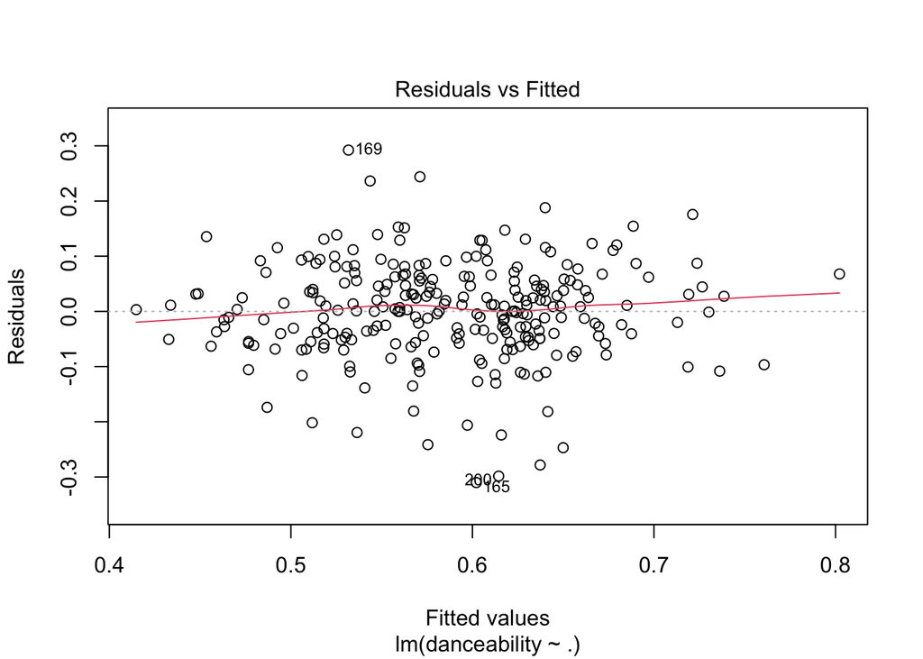

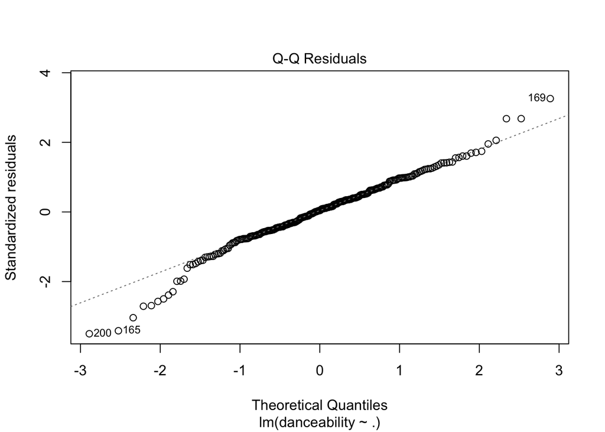

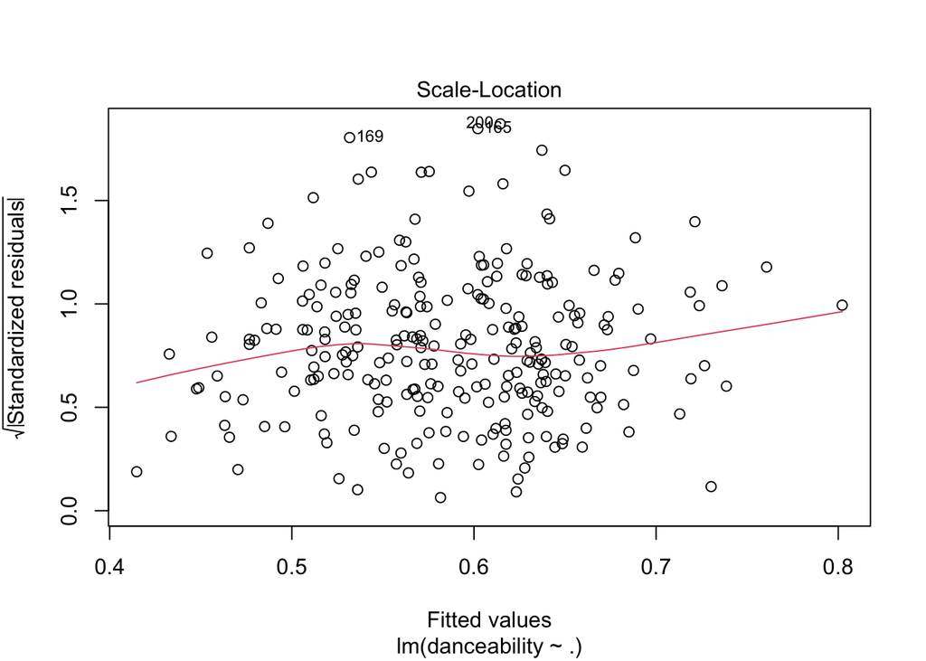

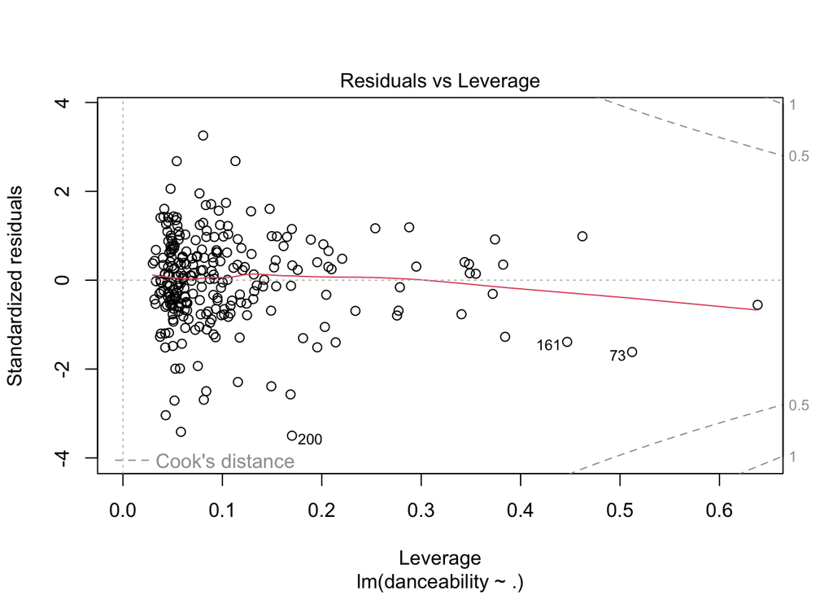

```r
plot(lm_model)
```

# Explanation of the four plots (from ChatGPT so be wary)

📈 1. Residuals vs Fitted What it shows: Residuals (errors) vs predicted values. You’re looking for: A random scatter of points around the horizontal line (0).

✅ Good: Cloud of dots, no pattern → model fits well.

❌ Bad: Curves, funnels, or patterns → non-linearity or heteroscedasticity.

TL;DR: If this plot looks like a sad banana, your model isn’t fully linear.

📉 2. Normal Q-Q Plot What it shows: Do your residuals follow a normal distribution? You’re looking for: Points hugging the 45° line.

✅ Good: Almost all dots are on or near the line.

❌ Bad: Points deviate sharply at the ends → skewed errors or outliers.

TL;DR: If it curves like a Taylor Swift bridge, your residuals might be a little dramatic.

🌡️ 3. Scale-Location (aka Spread-Location) What it shows: Do residuals have equal variance across fitted values? You’re looking for: A flat horizontal line with evenly spread points.

✅ Good: Dots are evenly spread.

❌ Bad: Dots fan out or funnel in → your residuals aren’t playing fair (heteroscedasticity).

TL;DR: If it looks like a trumpet, your errors are not consistent.

🔎 4. Residuals vs Leverage What it shows: Influential observations that might be messing with your model. You’re looking for: Points with high leverage and large residuals (check for red Cook’s distance circles).

✅ Good: Most points are in the middle, none flying solo in the corners.

❌ Bad: One point way off in the top-right? That’s your diva outlier.

TL;DR: If it looks like one data point’s trying to hijack your tour bus, investigate it.